# EasyVisa Project

## Context:

Business communities in the United States are facing high demand for human resources, but one of the constant challenges is identifying and attracting the right talent, which is perhaps the most important element in remaining competitive. Companies in the United States look for hard-working, talented, and qualified individuals both locally as well as abroad.

The Immigration and Nationality Act (INA) of the US permits foreign workers to come to the United States to work on either a temporary or permanent basis. The act also protects US workers against adverse impacts on their wages or working conditions by ensuring US employers' compliance with statutory requirements when they hire foreign workers to fill workforce shortages. The immigration programs are administered by the Office of Foreign Labor Certification (OFLC).

OFLC processes job certification applications for employers seeking to bring foreign workers into the United States and grants certifications in those cases where employers can demonstrate that there are not sufficient US workers available to perform the work at wages that meet or exceed the wage paid for the occupation in the area of intended employment.

## Objective:

In FY 2016, the OFLC processed 775,979 employer applications for 1,699,957 positions for temporary and permanent labor certifications. This was a nine percent increase in the overall number of processed applications from the previous year. The process of reviewing every case is becoming a tedious task as the number of applicants is increasing every year.

The increasing number of applicants every year calls for a Machine Learning based solution that can help in shortlisting the candidates having higher chances of VISA approval. OFLC has hired your firm EasyVisa for data-driven solutions. You as a data scientist have to analyze the data provided and, with the help of a classification model:

- Facilitate the process of visa approvals.
- Recommend a suitable profile for the applicants for whom the visa should be certified or denied based on the drivers that significantly influence the case status.

## Data Description

The data contains the different attributes of the employee and the employer. The detailed data dictionary is given below.

- case_id: ID of each visa application
- continent: Information of continent the employee
- education_of_employee: Information of education of the employee
- has_job_experience: Does the employee has any job experience? Y= Yes; N = No
- requires_job_training: Does the employee require any job training? Y = Yes; N = No
- no_of_employees: Number of employees in the employer's company
- yr_of_estab: Year in which the employer's company was established
- region_of_employment: Information of foreign worker's intended region of employment in the US.
- prevailing_wage: Average wage paid to similarly employed workers in a specific occupation in the area of intended employment. The purpose of the prevailing wage is to ensure that the foreign worker is not underpaid compared to other workers offering the same or similar service in the same area of employment.
- unit_of_wage: Unit of prevailing wage. Values include Hourly, Weekly, Monthly, and Yearly.
- full_time_position: Is the position of work full-time? Y = Full Time Position; N = Part Time Position
- case_status: Flag indicating if the Visa was certified or denied

### Stefhany Rodriguez - Ensemble techniques project

## Importing necessary libraries and data

```python
# Installing the libraries with the specified version.
#!pip install numpy==1.25.2 pandas==1.5.3 scikit-learn==1.2.2 matplotlib==3.7.1 seaborn==0.13.1 xgboost==2.0.3
```

```python
import warnings

warnings.filterwarnings("ignore")

# Libraries to help with reading and manipulating data
import numpy as np
import pandas as pd

# Library to split data
from sklearn.model_selection import train_test_split

# libaries to help with data visualization
import matplotlib.pyplot as plt
import seaborn as sns

# Removes the limit for the number of displayed columns
pd.set_option("display.max_columns", None)
# Sets the limit for the number of displayed rows
pd.set_option("display.max_rows", 100)


# Libraries different ensemble classifiers
from sklearn.ensemble import (
    BaggingClassifier,
    RandomForestClassifier,
    AdaBoostClassifier,
    GradientBoostingClassifier,
    StackingClassifier,
)

from sklearn.linear_model import LogisticRegression  # Import Logistic Regression

from xgboost import XGBClassifier
from sklearn.tree import DecisionTreeClassifier

# Libraries to get different metric scores
from sklearn import metrics
from sklearn.metrics import (
    confusion_matrix,
    accuracy_score,
    precision_score,
    recall_score,
    f1_score,
)

# To tune different models
from sklearn.model_selection import GridSearchCV
```

**Note**: *After running the above cell, kindly restart the notebook kernel and run all cells sequentially from the start again.*

```python
df_main = pd.read_csv("EasyVisa.csv")
```

```python
# copying data to another variable to avoid any changes to original data
data = df_main.copy()
```

## Data Overview

- Observations
- Sanity checks

```python
# Displaying the first 5 rows
data.head()
```

|  | case_id | continent | education_of_employee | has_job_experience | requires_job_training | no_of_employees | yr_of_estab | region_of_employment | prevailing_wage | unit_of_wage | full_time_position | case_status |
| --- | --- | --- | --- | --- | --- | --- | --- | --- | --- | --- | --- | --- |
| 0 | EZYV01 | Asia | High School | N | N | 14513 | 2007 | West | 592.2029 | Hour | Y | Denied |
| 1 | EZYV02 | Asia | Master's | Y | N | 2412 | 2002 | Northeast | 83425.6500 | Year | Y | Certified |
| 2 | EZYV03 | Asia | Bachelor's | N | Y | 44444 | 2008 | West | 122996.8600 | Year | Y | Denied |
| 3 | EZYV04 | Asia | Bachelor's | N | N | 98 | 1897 | West | 83434.0300 | Year | Y | Denied |
| 4 | EZYV05 | Africa | Master's | Y | N | 1082 | 2005 | South | 149907.3900 | Year | Y | Certified |

```python
# Displaying the last 5 rows
data.tail()
```

|  | case_id | continent | education_of_employee | has_job_experience | requires_job_training | no_of_employees | yr_of_estab | region_of_employment | prevailing_wage | unit_of_wage | full_time_position | case_status |
| --- | --- | --- | --- | --- | --- | --- | --- | --- | --- | --- | --- | --- |
| 25475 | EZYV25476 | Asia | Bachelor's | Y | Y | 2601 | 2008 | South | 77092.57 | Year | Y | Certified |
| 25476 | EZYV25477 | Asia | High School | Y | N | 3274 | 2006 | Northeast | 279174.79 | Year | Y | Certified |
| 25477 | EZYV25478 | Asia | Master's | Y | N | 1121 | 1910 | South | 146298.85 | Year | N | Certified |
| 25478 | EZYV25479 | Asia | Master's | Y | Y | 1918 | 1887 | West | 86154.77 | Year | Y | Certified |
| 25479 | EZYV25480 | Asia | Bachelor's | Y | N | 3195 | 1960 | Midwest | 70876.91 | Year | Y | Certified |

```python
#shape returns a tuple with the number of rows and columns
rows, columns = data.shape
print('The dataset has', rows, 'rows.')
print('The dataset has', columns, 'columns.')
```

```
The dataset has 25480 rows.
The dataset has 12 columns.
```

### Data types of the columns for the dataset

```python
data.info()
```

```
<class 'pandas.core.frame.DataFrame'>
RangeIndex: 25480 entries, 0 to 25479
Data columns (total 12 columns):
 #   Column                 Non-Null Count  Dtype
---  ------                 --------------  -----
 0   case_id                25480 non-null  object
 1   continent              25480 non-null  object
 2   education_of_employee  25480 non-null  object
 3   has_job_experience     25480 non-null  object
 4   requires_job_training  25480 non-null  object
 5   no_of_employees        25480 non-null  int64
 6   yr_of_estab            25480 non-null  int64
 7   region_of_employment   25480 non-null  object
 8   prevailing_wage        25480 non-null  float64
 9   unit_of_wage           25480 non-null  object
 10  full_time_position     25480 non-null  object
 11  case_status            25480 non-null  object
dtypes: float64(1), int64(2), object(9)
memory usage: 2.3+ MB
```

- Here I can evidence the 3 different data types of the columns in the data frame: object, float and int.
- case_id, continent, education of employee, has job experience, requires job training, region of employment, unit of wage, full time position and case_status are objects, used to represent string type-boolean
- No_of_employees and yr_of_estab are integer type.
- Prevailing_wage is float type.

```python
#.describe() gives a summary statistical for a numerical column by default
data.describe().T
```

|  | count | mean | std | min | 25% | 50% | 75% | max |
| --- | --- | --- | --- | --- | --- | --- | --- | --- |
| no_of_employees | 25480.0 | 5667.043210 | 22877.928848 | -26.0000 | 1022.00 | 2109.00 | 3504.0000 | 602069.00 |
| yr_of_estab | 25480.0 | 1979.409929 | 42.366929 | 1800.0000 | 1976.00 | 1997.00 | 2005.0000 | 2016.00 |
| prevailing_wage | 25480.0 | 74455.814592 | 52815.942327 | 2.1367 | 34015.48 | 70308.21 | 107735.5125 | 319210.27 |

- Count, mean, std, min, 25%, 50%, 75%, max are provided for numerical variables, in this case, just 3 variables.

```python
data.describe(include=['object', 'category']).T
```

|  | count | unique | top | freq |
| --- | --- | --- | --- | --- |
| case_id | 25480 | 25480 | EZYV01 | 1 |
| continent | 25480 | 6 | Asia | 16861 |
| education_of_employee | 25480 | 4 | Bachelor's | 10234 |
| has_job_experience | 25480 | 2 | Y | 14802 |
| requires_job_training | 25480 | 2 | N | 22525 |
| region_of_employment | 25480 | 5 | Northeast | 7195 |
| unit_of_wage | 25480 | 4 | Year | 22962 |
| full_time_position | 25480 | 2 | Y | 22773 |
| case_status | 25480 | 2 | Certified | 17018 |

- For categorical variables pandas calculates: count, unique, top and freq.

### Duplicates

```python
# Check if there's any duplicates
duplicates= data.duplicated()
duplicates.sum()
```

```
0
```

- We can evidence there is no duplicated values.

## Exploratory Data Analysis (EDA)

- EDA is an important part of any project involving data.
- It is important to investigate and understand the data better before building a model with it.
- A few questions have been mentioned below which will help you approach the analysis in the right manner and generate insights from the data.
- A thorough analysis of the data, in addition to the questions mentioned below, should be done.

#### Fixing the negative values in number of employees columns

```python
# Checkig the negative values in the employee column
data.loc[data['no_of_employees'] < 0].shape
```

```
(33, 12)
```

```python
# abs() returns the absolute value of each element in the no_of_employees column making sure all values are non-negative
data["no_of_employees"] = abs(data["no_of_employees"])
```

### Checking the count of each unique category in each of the categorical variables

```python
# Making a list of all catrgorical variables
cat_col = list(data.select_dtypes("object").columns)

# Printing number of count of each unique value in each column
for column in cat_col:
    print(data[column].value_counts())
    print("-" * 50)
```

```
continent
Asia             16861
Europe            3732
North America     3292
South America      852
Africa             551
Oceania            192
Name: count, dtype: int64
--------------------------------------------------
education_of_employee
Bachelor's     10234
Master's        9634
High School     3420
Doctorate       2192
Name: count, dtype: int64
--------------------------------------------------
has_job_experience
Y    14802
N    10678
Name: count, dtype: int64
--------------------------------------------------
requires_job_training
N    22525
Y     2955
Name: count, dtype: int64
--------------------------------------------------
region_of_employment
Northeast    7195
South        7017
West         6586
Midwest      4307
Island        375
Name: count, dtype: int64
--------------------------------------------------
unit_of_wage
Year     22962
Hour      2157
Week       272
Month       89
Name: count, dtype: int64
--------------------------------------------------
full_time_position
Y    22773
N     2707
Name: count, dtype: int64
--------------------------------------------------
```

- The majority of applicants are from Asia (16,861), followed by Europe (3,732) and North America (3,292).
- The highest number of applicants have a Bachelor’s degree (10,234) or a Master’s degree (9,634).
- Yes: 14,802 applicants have prior job experience.
- No: 22,525 applicants do not require job training.
- Jobs are mainly located in the Northeast (7,195), South (7,017), and West (6,586) of US.
- Yearly wage (22,962 applicants) is the most common, indicating that most job offers are for full-time positions.

```python
# checking the number of unique values of case_id
data["case_id"].nunique()
```

```
25480
```

- case_id has same size of the rows of the data set: 25480

```python
# dropping 'case_id' column from the data.
# axis=1: Indicates that we are dropping a column (not a row).
# inplace=True: Modifies the DataFrame directly instead of creating a new one.
data.drop(["case_id"], axis=1, inplace=True)
```

- We drop case_id because it is a unique identifier for each row and does not give any useful information for prediction.

## Univariate analysis & bivariate analysis along with the questions

```python
def histogram_boxplot(data, feature, figsize=(15, 10), kde=False, bins=None):
    """
    Boxplot and histogram combined

    data: dataframe
    feature: dataframe column
    figsize: size of figure (default (15,10))
    kde: whether to show the density curve (default False)
    bins: number of bins for histogram (default None)
    """
    f2, (ax_box2, ax_hist2) = plt.subplots(
        nrows=2,  # Number of rows of the subplot grid= 2
        sharex=True,  # x-axis will be shared among all subplots
        gridspec_kw={"height_ratios": (0.25, 0.75)},
        figsize=figsize,
    )  # creating the 2 subplots
    sns.boxplot(
        data=data, x=feature, ax=ax_box2, showmeans=True, color="violet"
    )  # boxplot will be created and a triangle will indicate the mean value of the column
    sns.histplot(
        data=data, x=feature, kde=kde, ax=ax_hist2, bins=bins
    ) if bins else sns.histplot(
        data=data, x=feature, kde=kde, ax=ax_hist2
    )  # For histogram
    ax_hist2.axvline(
        data[feature].mean(), color="green", linestyle="--"
    )  # Add mean to the histogram
    ax_hist2.axvline(
        data[feature].median(), color="black", linestyle="-"
    )  # Add median to the histogram
```

```python
# function to create labeled barplots

def labeled_barplot(data, feature, perc=False, n=None):
    """
    Barplot with percentage at the top

    data: dataframe
    feature: dataframe column
    perc: whether to display percentages instead of count (default is False)
    n: displays the top n category levels (default is None, i.e., display all levels)
    """

    total = len(data[feature])  # length of the column
    count = data[feature].nunique()
    if n is None:
        plt.figure(figsize=(count + 2, 6))
    else:
        plt.figure(figsize=(n + 2, 6))

    plt.xticks(rotation=90, fontsize=15)
    ax = sns.countplot(
        data=data,
        x=feature,
        palette="Paired",
        order=data[feature].value_counts().index[:n],
    )

    for p in ax.patches:
        if perc == True:
            label = "{:.1f}%".format(
                100 * p.get_height() / total
            )  # percentage of each class of the category
        else:
            label = p.get_height()  # count of each level of the category

        x = p.get_x() + p.get_width() / 2  # width of the plot
        y = p.get_height()  # height of the plot

        ax.annotate(
            label,
            (x, y),
            ha="center",
            va="center",
            size=12,
            xytext=(0, 5),
            textcoords="offset points",
        )  # annotate the percentage

    plt.show()  # show the plot
```

### Number of employees

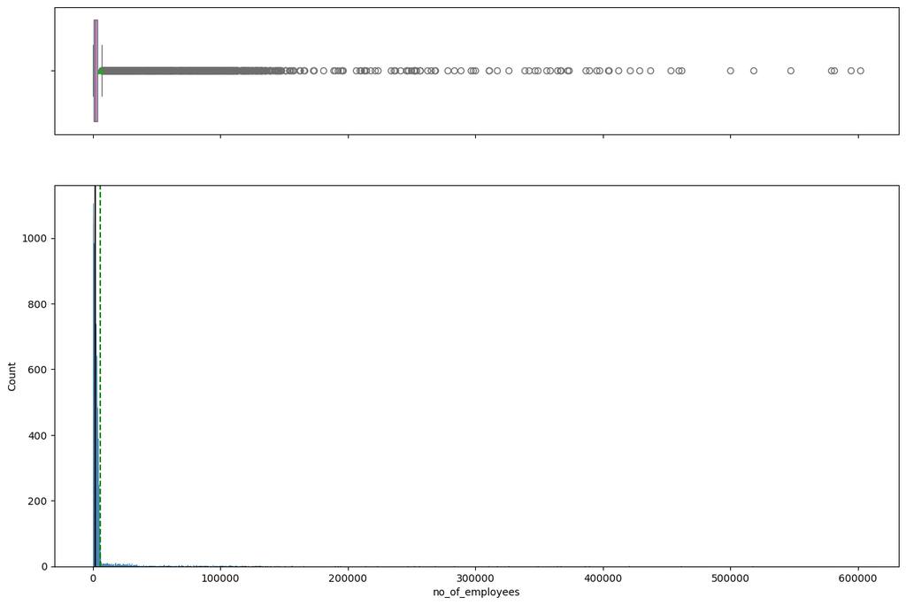

```python
histogram_boxplot(data, "no_of_employees")
```

- The boxplot shows many extreme outliers.
- The boxplot has highly skewed distribution with some very large values, most of the data points are concentrated on the left side, but a few extreme values (outliers) stretch the distribution significantly to the right.
- The histogram is mostly concentrated on the left side, most of businesses have a small number of employees.
- There are a few extreme large values causing the distribution to be highly right skewed.

### Prevailing wage

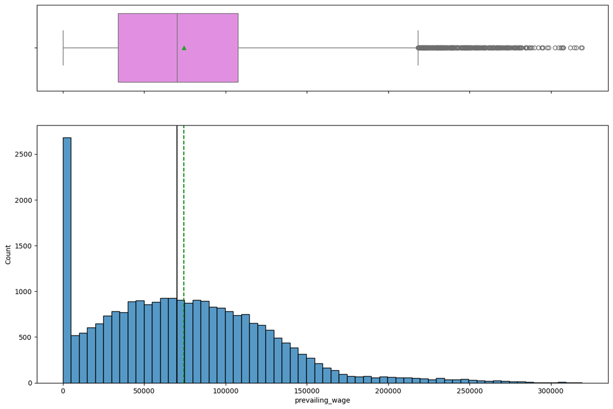

```python
histogram_boxplot(data, "prevailing_wage")
```

- Refering to the boxplot the interquartile range (IQR) covers a wide spread of values from 30000 to 100000.
- There are outliers on the end, but they are not as extreme as the "no_of_employees" variable.
- In the histogram the distribution appears to be right-skewed with a long tail on the right.
- There is a peak at very begging, which might indicate either data entry errors, a specific category of jobs, or part-time wages.
- The majority of values seem to be concentrated between 30,000 - $150,000 and then start to gradually decline beyond that.

### Continent

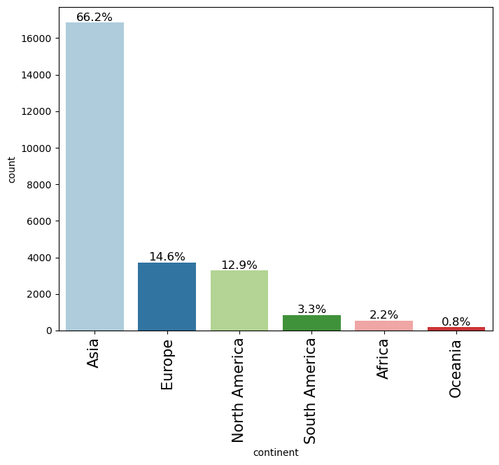

```python
labeled_barplot(data, "continent", perc=True)
```

- Asia has the 66.2% of the applications, which indicates that most applicants are from this region.
- Europe with 14.6% and North America with 12.9% have a considerable percentage of applications.
- South America (3.3%), Africa (2.2%), and Oceania (0.8%) have significantly fewer applicants.

### Education of employee

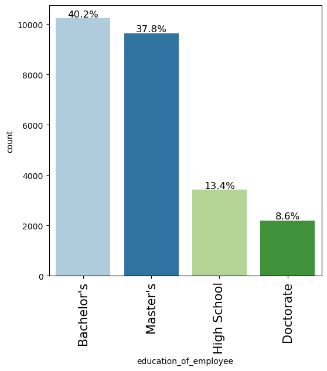

```python
labeled_barplot(data, "education_of_employee", perc=True)
```

- The majority of applicants have Bachelor’s (40.2%) and Master’s (37.8%) degrees, meaning almost 80% of visa applicants have at least an undergraduate or postgraduate degree.
- Lower representation of High School Graduates (13.4%)
- Doctorate Holders (8.6%). The smallest percentage suggests that few jobs require a doctoral degree compared to bachelor's or master's level jobs.

### Job experience

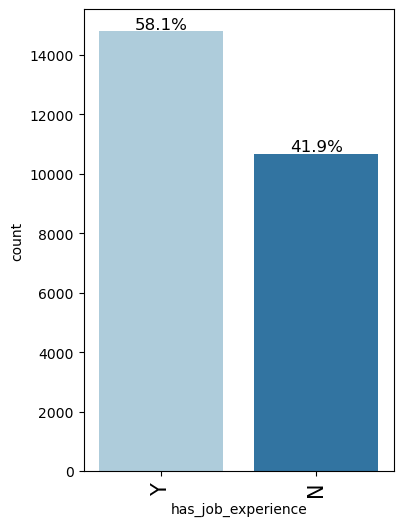

```python
labeled_barplot(data, "has_job_experience", perc=True)
```

- More than half of the applicants (58.1%) have work experience. An a significant part of applicants 41.9% don't have experience.
- This suggests that experienced professionals are more likely to apply for visas, and many jobs may require some level of experience.

### Job training

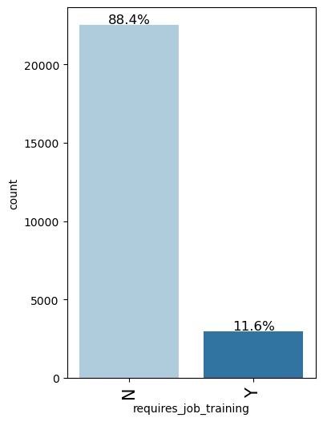

```python
labeled_barplot(data, "requires_job_training", perc=True)
```

- The majority of visa applicants (88.4%) do not need job training which suggests that most applicants already have the required skills for the job or has the job experience.
- Only 11.6% of applicants require job training, it can include fresh graduates.

### Region of employment

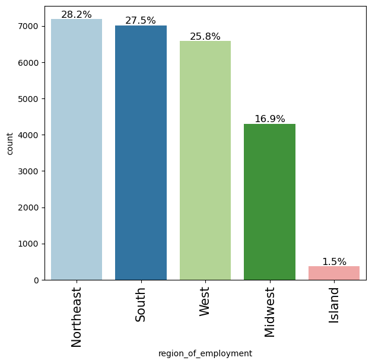

```python
labeled_barplot(data, "region_of_employment", perc=True)
```

### Unit of wage

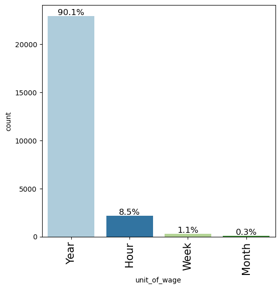

```python
labeled_barplot(data, "unit_of_wage", perc=True)
```

- The majority of visa applicants receive annual salaries with 90.1%, indicating that most job opportunities for foreign workers are stable and long-term.
- A small percentage of applicants are paid on an hourly basis with the 8.5%.
- Weekly (1.1%) and Monthly (0.3%) wage structures are rare.

## Bivariate analysis

### Correlation

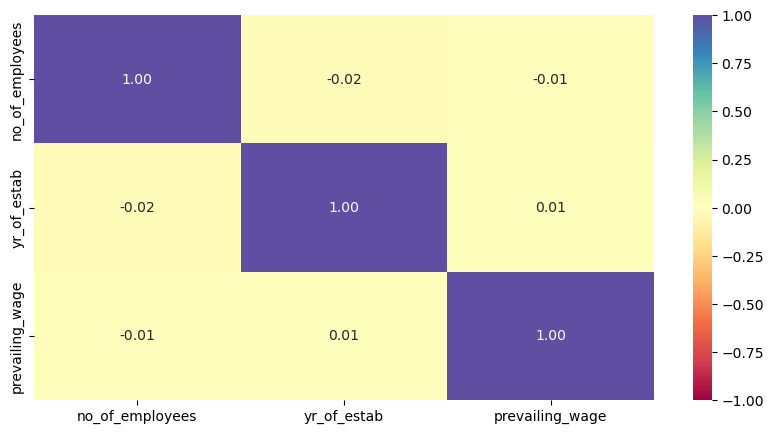

```python
cols_list = data.select_dtypes(include=np.number).columns.tolist()

plt.figure(figsize=(10, 5))

sns.heatmap(
    data[cols_list].corr(), annot=True, vmin=-1, vmax=1, fmt=".2f", cmap="Spectral"
)
```

- The graph shows the relationship between three variables: number of employees, year of establishment, and prevailing wage.
- The correlation between the number of employees and the prevailing wage is -0.01, indicating a very weak negative relationship.
- The correlation between the number of employees and the year of establishment is -0.02, indicating a very weak negative relationship.
- The correlation between the year of establishment and the prevailing wage is 0.01, indicating a very weak positive relationship.

**Leading Questions**:

1. Those with higher education may want to travel abroad for a well-paid job. Does education play a role in Visa certification?
2. How does the visa status vary across different continents?
3. Experienced professionals might look abroad for opportunities to improve their lifestyles and career development. Does work experience influence visa status?
4. In the United States, employees are paid at different intervals. Which pay unit is most likely to be certified for a visa?
5. The US government has established a prevailing wage to protect local talent and foreign workers. How does the visa status change with the prevailing wage?

### 1. Those with higher education may want to travel abroad for a well-paid job. Does education play a role in Visa certification?

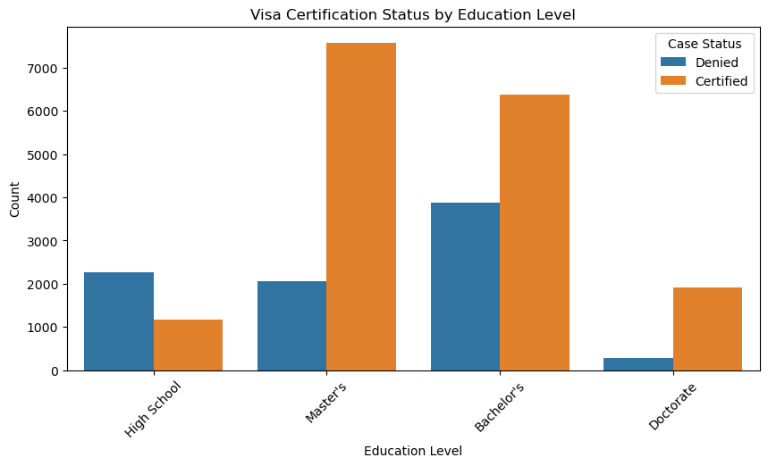

```python
plt.figure(figsize=(10, 5))
sns.countplot(data=data, x="education_of_employee", hue="case_status")
plt.xticks(rotation=45)
plt.title("Visa Certification Status by Education Level")
plt.xlabel("Education Level")
plt.ylabel("Count")
plt.legend(title="Case Status")
plt.show()
```

```python
# Groups the dataset based on the "education_of_employee" column. I'm gonna analyze visa certification status separately for each education level.
#Converts the results into a tabular format.
edu_approval_rates = data.groupby("education_of_employee")["case_status"].value_counts(normalize=True).unstack()
print(edu_approval_rates)
```

```
case_status            Certified    Denied
education_of_employee
Bachelor's              0.622142  0.377858
Doctorate               0.872263  0.127737
High School             0.340351  0.659649
Master's                0.786278  0.213722
```

### 2. How does the visa status vary across different continents?

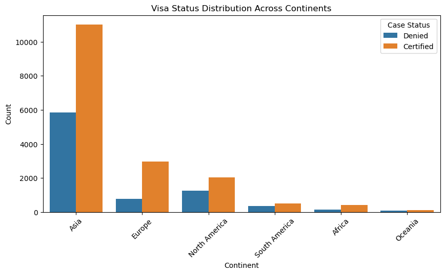

```python
plt.figure(figsize=(10, 5))
sns.countplot(data=data, x="continent", hue="case_status", order=data["continent"].value_counts().index)
plt.xticks(rotation=45)
plt.title("Visa Status Distribution Across Continents")
plt.xlabel("Continent")
plt.ylabel("Count")
plt.legend(title="Case Status")
plt.show()
```

- Asia has the highest count of certified visas, followed by Europe and North America.
- South America, Africa, and Oceania have significantly lower counts of certified visas compared to Asia, Europe, and North America, also because there are fewer applicants in these regions.
- The number of denied visas is also higher in Asia, Europe, and North America compared to other continents.

```python
continent_approval_rates = data.groupby("continent")["case_status"].value_counts(normalize=True).unstack()
print(continent_approval_rates)
```

```
case_status    Certified    Denied
continent
Africa          0.720508  0.279492
Asia            0.653105  0.346895
Europe          0.792337  0.207663
North America   0.618773  0.381227
Oceania         0.635417  0.364583
South America   0.578638  0.421362
```

### 3. Experienced professionals might look abroad for opportunities to improve their lifestyles and career development. Does work experience influence visa status?

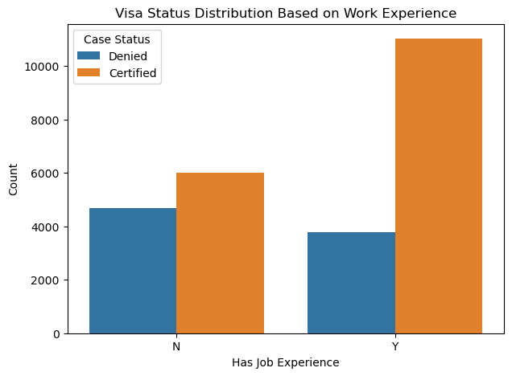

```python
plt.figure(figsize=(7, 5))
sns.countplot(data=data, x="has_job_experience", hue="case_status")
plt.title("Visa Status Distribution Based on Work Experience")
plt.xlabel("Has Job Experience")
plt.ylabel("Count")
plt.legend(title="Case Status")
plt.show()
```

```python
experience_approval_rates = data.groupby("has_job_experience")["case_status"].value_counts(normalize=True).unstack()
print(experience_approval_rates)
```

```
case_status         Certified    Denied
has_job_experience
N                    0.561341  0.438659
Y                    0.744764  0.255236
```

- Applicants with job experience have a higher count of certified visas compared to those without job experience.
- 74.48% of experienced applicants (Y) got their visas certified, compared to 56.13% for inexperienced applicants (N). This indicates that having work experience improves the chances of visa approval.
- 43.87% of applicants without experience got their visa denied, compared to only 25.52% for experienced applicants. This indicates that lack of job experience increases the probability of visa denial.
- Work experience have a significant impact of visa approval rates.
- Work experience plays a role in visa certification, with experienced professionals having better chances of getting a visa.

### 4. In the United States, employees are paid at different intervals. Which pay unit is most likely to be certified for a visa?

[figure not shown]

```python
plt.figure(figsize=(8, 5))
sns.countplot(data=data, x="unit_of_wage", hue="case_status", palette="Set2")
plt.title("Visa Certification by Pay Unit")
plt.xlabel("Unit of Wage")
plt.ylabel("Count")
plt.legend(title="Case Status", labels=["Certified", "Denied"])
plt.xticks(rotation=45)  # Rotate labels for better readability
plt.show()
```

```python
wage_approval_rates = data.groupby("unit_of_wage")["case_status"].value_counts(normalize=True).unstack()
print(wage_approval_rates)
```

```
case_status   Certified    Denied
unit_of_wage
Hour           0.346314  0.653686
Month          0.617978  0.382022
Week           0.621324  0.378676
Year           0.698850  0.301150
```

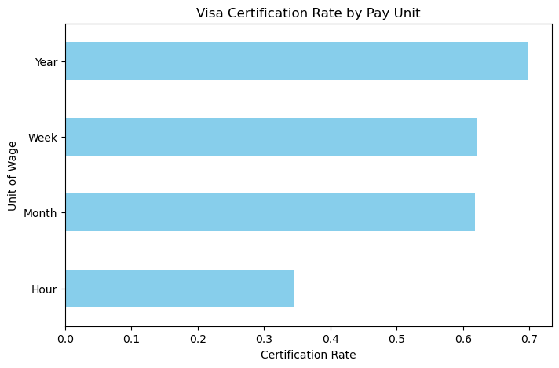

```python
plt.figure(figsize=(8, 5))
wage_plot = wage_approval_rates["Certified"].sort_values().plot(kind="barh", color="skyblue")
plt.title("Visa Certification Rate by Pay Unit")
plt.xlabel("Certification Rate")
plt.ylabel("Unit of Wage")
plt.show()
```

- 69.89% of applicants with yearly salaries got their visas certified, making it the most favorable pay unit for approval.
- Hourly wage has the highest denial rate. Only 34.63% of hourly wage applicants were approved, while 65.37% were denied.This suggests that hourly jobs are less likely to be approved.
- Monthly and Weekly wages have similar approval rates around 61-62% certified, meaning they are more favorable than hourly but less than yearly wages.

### 5. The US government has established a prevailing wage to protect local talent and foreign workers. How does the visa status change with the prevailing wage?

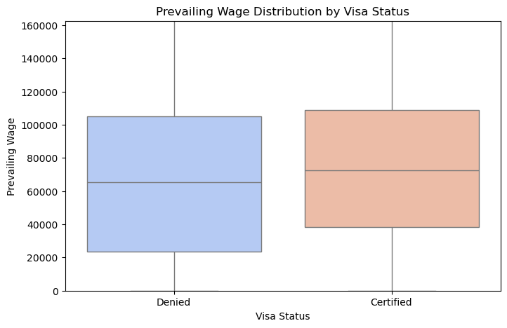

```python
plt.figure(figsize=(8, 5))
sns.boxplot(data=data, x="case_status", y="prevailing_wage", palette="coolwarm")
plt.ylim(0, data["prevailing_wage"].quantile(0.95))  # Remove extreme outliers for better visualization
plt.title("Prevailing Wage Distribution by Visa Status")
plt.xlabel("Visa Status")
plt.ylabel("Prevailing Wage")
plt.show()
```

```python
data.groupby("case_status")["prevailing_wage"].mean()
```

```
case_status
Certified    77293.619243
Denied       68748.681580
Name: prevailing_wage, dtype: float64
```

### Check if the prevailing wage is similar across all the regions of the US

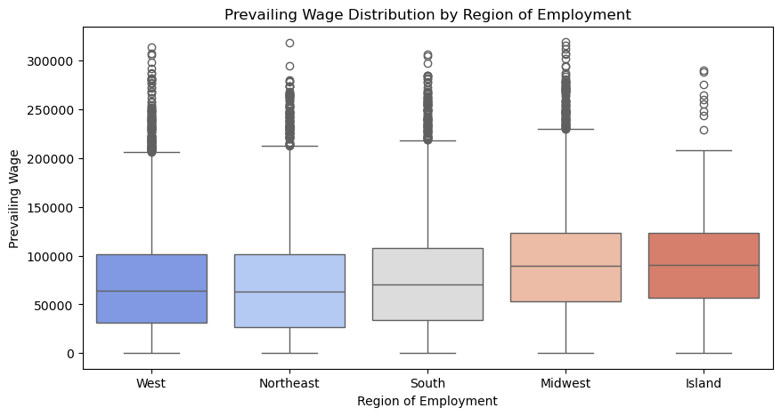

```python
plt.figure(figsize=(10, 5))
sns.boxplot(data=data, x="region_of_employment", y="prevailing_wage", palette="coolwarm")
plt.xticks(rotation=0)
plt.title("Prevailing Wage Distribution by Region of Employment")
plt.xlabel("Region of Employment")
plt.ylabel("Prevailing Wage")
plt.show()
```

- The median wages for all regions appear to be relatively similar, suggesting that the central tendency of wages does not differ drastically.
- The Island and Midwest region seem to have a slightly higher median than the other regions.
- The IQR is similar across all regions.
- All regions show a significant number of outliers above 200.000, indicating that some jobs offer significantly higher wages.

### Employees who have prior work experience require any job training?

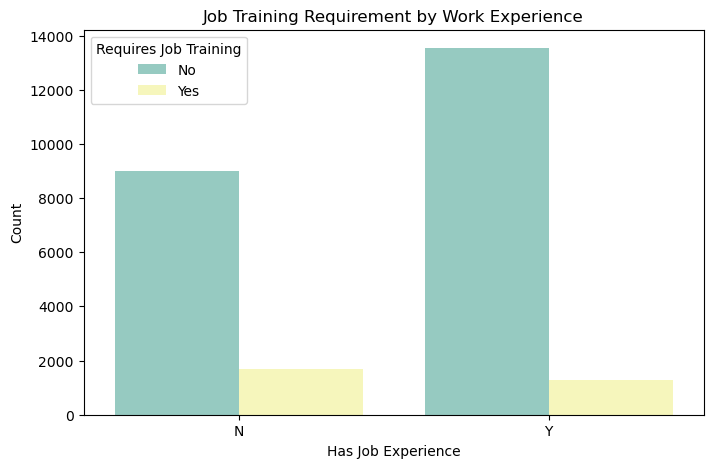

```python
plt.figure(figsize=(8, 5))
sns.countplot(data=data, x="has_job_experience", hue="requires_job_training", palette="Set3")
plt.title("Job Training Requirement by Work Experience")
plt.xlabel("Has Job Experience")
plt.ylabel("Count")
plt.legend(title="Requires Job Training", labels=["No", "Yes"])
plt.show()
```

- The graph indicates that employees with work experience are less likely to require job training compared to those without experience.
- However, there is still a percentage of experienced applicants who need training. It can lead to the conclusion that job training requirements can depend on the specific job, regardless of experience.

## Data Preprocessing

- Missing value treatment (if needed)
- Feature engineering
- Outlier detection and treatment (if needed)
- Preparing data for modeling
- Any other preprocessing steps (if needed)

### Outlier detection

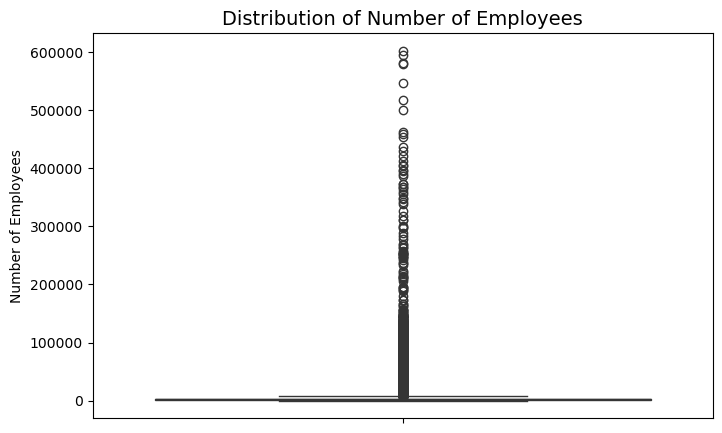

```python
# Set figure size
plt.figure(figsize=(8, 5))

# Create the boxplot for "no_of_employees"
sns.boxplot(y=data["no_of_employees"], palette="viridis")  # You can change the color palette

# Add title and labels
plt.title("Distribution of Number of Employees", fontsize=14)
plt.ylabel("Number of Employees")

# Show the plot
```

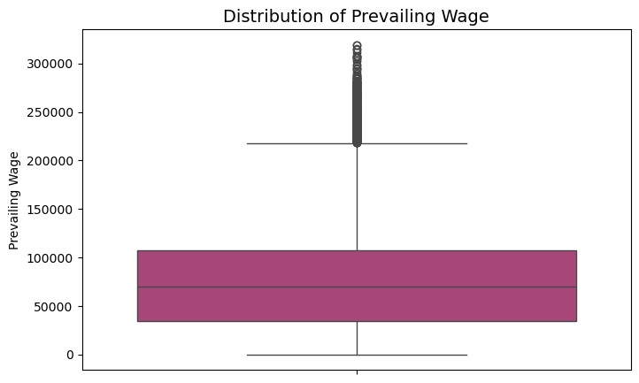

```python
# Set figure size
plt.figure(figsize=(8, 5))

# Create the boxplot for "prevailing_wage"
sns.boxplot(y=data["prevailing_wage"], palette="magma")  # You can change the color palette

# Add title and labels
plt.title("Distribution of Prevailing Wage", fontsize=14)
plt.ylabel("Prevailing Wage")

# Show the plot
```

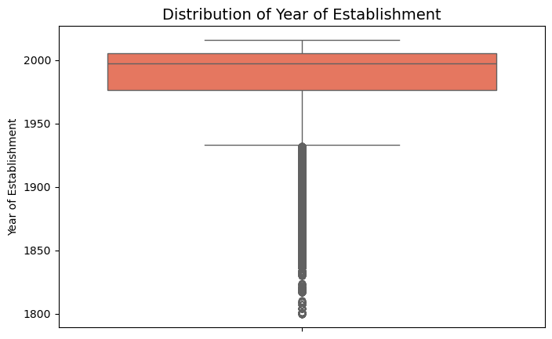

```python
# Set figure size
plt.figure(figsize=(8, 5))

# Create the boxplot for "yr_of_estab"
sns.boxplot(y=data["yr_of_estab"], palette="Reds")  # You can change the color palette

# Add title and labels
plt.title("Distribution of Year of Establishment", fontsize=14)
plt.ylabel("Year of Establishment")

# Show the plot
plt.show()
```

### Preparing data for modelling

```python
# Convert 'case_status' to binary (1 = Certified, 0 = Denied)
data["case_status"] = data["case_status"].apply(lambda x: 1 if x == "Certified" else 0)

# Drop 'case_status' from the feature set
X = data.drop("case_status", axis=1)

# Define the target variable
Y = data["case_status"]

# Convert categorical variables into dummy variables
X = pd.get_dummies(X, drop_first=True)

# Splitting data into training (70%) and testing (30%) sets
X_train, X_test, y_train, y_test = train_test_split(X, Y, test_size=0.3, random_state=1, stratify=Y)
```

```python
print("Shape of Training set : ", X_train.shape)
print("Shape of test set : ", X_test.shape)
print("Percentage of classes in training set:")
print(y_train.value_counts(normalize=True))
print("Percentage of classes in test set:")
print(y_test.value_counts(normalize=True))
```

```
Shape of Training set :  (17836, 21)
Shape of test set :  (7644, 21)
Percentage of classes in training set:
case_status
1    0.667919
0    0.332081
Name: proportion, dtype: float64
Percentage of classes in test set:
case_status
1    0.667844
0    0.332156
Name: proportion, dtype: float64
```

## Building bagging and boosting models

**Note**

1. Sample parameter grids have been provided to do necessary hyperparameter tuning. These sample grids are expected to provide a balance between model performance improvement and execution time. One can extend/reduce the parameter grid based on execution time and system configuration.
- Please note that if the parameter grid is extended to improve the model performance further, the execution time will increase
- For Gradient Boosting:

```
param_grid = {
    "init": [AdaBoostClassifier(random_state=1),DecisionTreeClassifier(random_state=1)],
    "n_estimators": np.arange(50,110,25),
    "learning_rate": [0.01,0.1,0.05],
    "subsample":[0.7,0.9],
    "max_features":[0.5,0.7,1],
}
```

- For Adaboost:

```
param_grid = {
    "n_estimators": np.arange(50,110,25),
    "learning_rate": [0.01,0.1,0.05],
    "base_estimator": [
        DecisionTreeClassifier(max_depth=2, random_state=1),
        DecisionTreeClassifier(max_depth=3, random_state=1),
    ],
}
```

- For Bagging Classifier:

```
param_grid = {
    'max_samples': [0.8,0.9,1],
    'max_features': [0.7,0.8,0.9],
    'n_estimators' : [30,50,70],
}
```

- For Random Forest:

```
param_grid = {
    "n_estimators": [50,110,25],
    "min_samples_leaf": np.arange(1, 4),
    "max_features": [np.arange(0.3, 0.6, 0.1),'sqrt'],
    "max_samples": np.arange(0.4, 0.7, 0.1)
}
```

- For Decision Trees:

```
param_grid = {
    'max_depth': np.arange(2,6),
    'min_samples_leaf': [1, 4, 7],
    'max_leaf_nodes' : [10, 15],
    'min_impurity_decrease': [0.0001,0.001]
}
```

- For XGBoost:

```
param_grid={'n_estimators':np.arange(50,110,25),
            'scale_pos_weight':[1,2,5],
            'learning_rate':[0.01,0.1,0.05],
            'gamma':[1,3],
            'subsample':[0.7,0.9]
}
```

```python
# defining a function to compute different metrics to check performance of a classification model built using sklearn


def model_performance_classification_sklearn(model, predictors, target):
    """
    Function to compute different metrics to check classification model performance

    model: classifier
    predictors: independent variables
    target: dependent variable
    """

    # predicting using the independent variables
    pred = model.predict(predictors)

    acc = accuracy_score(target, pred)  # to compute Accuracy
    recall = recall_score(target, pred)  # to compute Recall
    precision = precision_score(target, pred)  # to compute Precision
    f1 = f1_score(target, pred)  # to compute F1-score

    # creating a dataframe of metrics
    df_perf = pd.DataFrame(
        {"Accuracy": acc, "Recall": recall, "Precision": precision, "F1": f1,},
        index=[0],
    )

    return df_perf
```

```python
def confusion_matrix_sklearn(model, predictors, target):
    """
    To plot the confusion_matrix with percentages

    model: classifier
    predictors: independent variables
    target: dependent variable
    """
    y_pred = model.predict(predictors)
    cm = confusion_matrix(target, y_pred)
    labels = np.asarray(
        [
            ["{0:0.0f}".format(item) + "\n{0:.2%}".format(item / cm.flatten().sum())]
            for item in cm.flatten()
        ]
    ).reshape(2, 2)

    plt.figure(figsize=(6, 4))
    sns.heatmap(cm, annot=labels, fmt="")
    plt.ylabel("True label")
    plt.xlabel("Predicted label")
```

## Will tuning the hyperparameters improve the model performance?

- I'm going to evaluate each technique both with and without hyperparameter tuning to compare their performance. This will help determine how much improvement tuning provides over the baseline model.
- Sample parameter grids provided were used over the project.
- Below, each technique will be detailed individually.

## Bagging

### Decision tree

```python
# Define the Decision Tree model with random_state = 1
model = DecisionTreeClassifier(random_state=1)

# Fit the model on the training data
model.fit(X_train, y_train)
```

```
DecisionTreeClassifier(random_state=1)
```

#### Train data

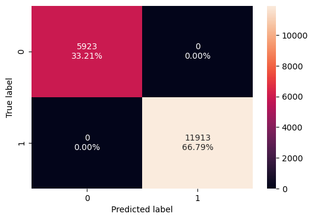

```python
confusion_matrix_sklearn(model, X_train, y_train)
```

```python
decision_tree_perf_train = model_performance_classification_sklearn(model, X_train, y_train)
decision_tree_perf_train
```

|  | Accuracy | Recall | Precision | F1 |
| --- | --- | --- | --- | --- |
| 0 | 1.0 | 1.0 | 1.0 | 1.0 |

#### Test data

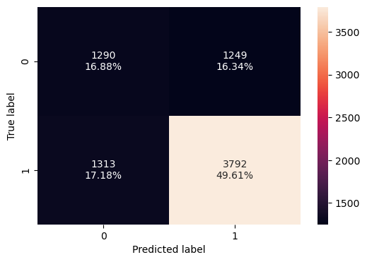

```python
# Create confusion matrix for test data
confusion_matrix_sklearn(model, X_test, y_test)
```

```python
# Check performance on test data
decision_tree_perf_test = model_performance_classification_sklearn(model, X_test, y_test)
decision_tree_perf_test
```

|  | Accuracy | Recall | Precision | F1 |
| --- | --- | --- | --- | --- |
| 0 | 0.664835 | 0.742801 | 0.752232 | 0.747487 |

- Accuracy, Recall, Precision, and F1 Score are all 1.0, meaning the model perfectly classifies the training data. However this indicates overfitting
- The model is not generalizing patterns instead it has memorized the training data.

### Hyper parameter tunning decision tree

```python
param_grid = {
    'max_depth': np.arange(2,6),
    'min_samples_leaf': [1, 4, 7],
    'max_leaf_nodes' : [10, 15],
    'min_impurity_decrease': [0.0001,0.001]
}
```

```python
# Define the Decision Tree model
dtree = DecisionTreeClassifier(class_weight="balanced", random_state=1)

# Type of scoring used to compare parameter combinations
scorer = metrics.make_scorer(metrics.f1_score)

# Define GridSearchCV
grid_search = GridSearchCV(dtree, param_grid, cv=5, scoring=scorer, n_jobs=-1)

# Fit on training data
grid_search.fit(X_train, y_train)

# Print best parameters
print("Best Parameters:", grid_search.best_params_)

# Get the best model
best_dtree = grid_search.best_estimator_
```

```
Best Parameters: {'max_depth': 5, 'max_leaf_nodes': 10, 'min_impurity_decrease': 0.0001, 'min_samples_leaf': 1}
```

#### Train set

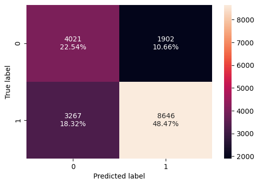

```python
confusion_matrix_sklearn(best_dtree, X_train, y_train)
```

```python
dtree_tuned_model_perf_train = model_performance_classification_sklearn(best_dtree, X_train, y_train)
dtree_tuned_model_perf_train
```

|  | Accuracy | Recall | Precision | F1 |
| --- | --- | --- | --- | --- |
| 0 | 0.710193 | 0.725762 | 0.819681 | 0.769868 |

#### Test set

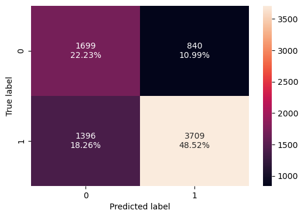

```python
confusion_matrix_sklearn(best_dtree, X_test, y_test)
```

```python
dtree_tuned_model_perf_test = model_performance_classification_sklearn(best_dtree, X_test, y_test)
dtree_tuned_model_perf_test
```

|  | Accuracy | Recall | Precision | F1 |
| --- | --- | --- | --- | --- |
| 0 | 0.707483 | 0.726543 | 0.815344 | 0.768386 |

- With the hyper parameter tunning decision tree we have no more an over fitted model.
- The best Parameters are: 'max_depth': 5, 'max_leaf_nodes': 10, 'min_impurity_decrease': 0.0001, 'min_samples_leaf': 1.
- The model performs similarly on both train and test sets, which is a good indicator.
- F1-score is 76.83% meaning that it balances precision and recall well.

### Bagging classifier

```python
# Define the Bagging Classifier with a random state
bagging_classifier = BaggingClassifier(random_state=1)

# Fit the Bagging Classifier on the training data
bagging_classifier.fit(X_train, y_train)
```

```
BaggingClassifier(random_state=1)
```

#### Train set

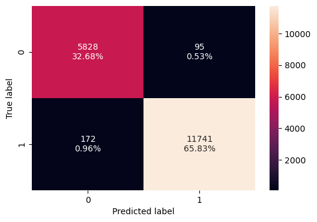

```python
# Create confusion matrix for train data
confusion_matrix_sklearn(bagging_classifier, X_train, y_train)
```

```python
bagging_classifier_model_train_perf = model_performance_classification_sklearn(bagging_classifier, X_train, y_train)
bagging_classifier_model_train_perf
```

|  | Accuracy | Recall | Precision | F1 |
| --- | --- | --- | --- | --- |
| 0 | 0.98503 | 0.985562 | 0.991974 | 0.988757 |

#### Test set

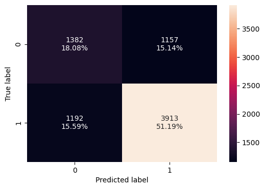

```python
# Create confusion matrix for train data
confusion_matrix_sklearn(bagging_classifier, X_test, y_test)
```

```python
bagging_classifier_model_test_perf = model_performance_classification_sklearn(bagging_classifier, X_test, y_test)
bagging_classifier_model_test_perf
```

|  | Accuracy | Recall | Precision | F1 |
| --- | --- | --- | --- | --- |
| 0 | 0.6927 | 0.766503 | 0.771795 | 0.76914 |

- The train accuracy is very high 98.5%, while the test accuracy drops to 69.27%.
- The model is clearly overfitting, memorizing patterns from the training data but it won't perform well with unseen data.

### Hyper parameter tunning bagging classifier

```python
# Define the Bagging Classifier
bagging_estimator_tuned = BaggingClassifier(random_state=1)

# Grid of parameters to choose from
param_grid_bagging = {
    'max_samples': [0.8, 0.9, 1],
    'max_features': [0.7, 0.8, 0.9],
    'n_estimators': [30, 50, 70],

}

# Type of scoring used to compare parameter combinations
acc_scorer = metrics.make_scorer(metrics.f1_score)

# Run the grid search with cross-validation (cv=5)
grid_obj = GridSearchCV(
    estimator=bagging_estimator_tuned,
    param_grid=param_grid_bagging,
    scoring=acc_scorer,
    cv=5,
    n_jobs=-1  # Uses all available CPU cores for faster computation
)

# Fit the Grid Search on the training data
grid_obj = grid_obj.fit(X_train, y_train)

# Set the classifier to the best combination of parameters
bagging_estimator_tuned = grid_obj.best_estimator_

# Fit the best algorithm to the data
bagging_estimator_tuned.fit(X_train, y_train)

# Print the best parameters found
print("Best parameters:", grid_obj.best_params_)
```

```
Best parameters: {'max_features': 0.7, 'max_samples': 0.8, 'n_estimators': 70}
```

#### Train set

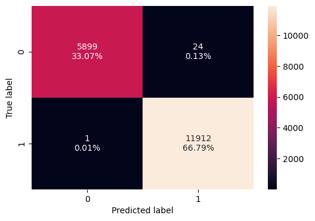

```python
# Generate confusion matrix for train data using the tuned Bagging Classifier
confusion_matrix_sklearn(bagging_estimator_tuned, X_train, y_train)
```

```python
bagging_estimator_tuned_model_train_perf = model_performance_classification_sklearn(bagging_estimator_tuned, X_train, y_train)
bagging_estimator_tuned_model_train_perf
```

|  | Accuracy | Recall | Precision | F1 |
| --- | --- | --- | --- | --- |
| 0 | 0.998598 | 0.999916 | 0.997989 | 0.998952 |

#### Test set

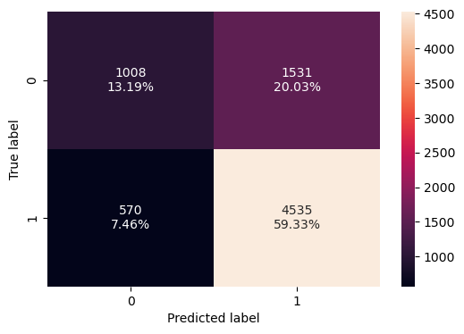

```python
confusion_matrix_sklearn(bagging_estimator_tuned, X_test, y_test)
```

```python
bagging_estimator_tuned_model_test_perf = model_performance_classification_sklearn(bagging_estimator_tuned, X_test, y_test)
bagging_estimator_tuned_model_test_perf
```

|  | Accuracy | Recall | Precision | F1 |
| --- | --- | --- | --- | --- |
| 0 | 0.725144 | 0.888345 | 0.74761 | 0.811924 |

- Even though we have improvements with Hyper parameter tunning bagging classifier, overfitting is still present.
- Recall improved from 76.65% to 88.83%, meaning the model now detects more visa approvals correctly.
- Not the best model even being a tunned model.

### Random Forest

```python
# Define the Random Forest Classifier
rf_estimator = RandomForestClassifier(random_state=1, class_weight="balanced")

# Fit the model on training data
rf_estimator.fit(X_train, y_train)
```

```
RandomForestClassifier(class_weight='balanced', random_state=1)
```

#### train set

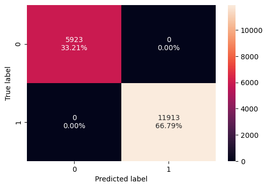

```python
confusion_matrix_sklearn(rf_estimator, X_train, y_train)
```

```python
rf_estimator_model_train_perf = model_performance_classification_sklearn(rf_estimator, X_train, y_train)
rf_estimator_model_train_perf
```

|  | Accuracy | Recall | Precision | F1 |
| --- | --- | --- | --- | --- |
| 0 | 1.0 | 1.0 | 1.0 | 1.0 |

#### test set

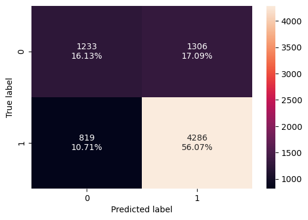

```python
confusion_matrix_sklearn(rf_estimator, X_test, y_test)
```

```python
rf_estimator_model_test_perf = model_performance_classification_sklearn(rf_estimator, X_test, y_test)
rf_estimator_model_test_perf
```

|  | Accuracy | Recall | Precision | F1 |
| --- | --- | --- | --- | --- |
| 0 | 0.722004 | 0.839569 | 0.766452 | 0.801346 |

- Random forest is overfitting, which is a major concern.

### Hyperparameter Tuning - Random Forest

```python
param_grid_rf = {
    "n_estimators": [50, 110, 25],  # Number of trees in the forest
    "min_samples_leaf": np.arange(1, 4),  # Minimum number of samples per leaf
    "max_features": list(np.arange(0.3, 0.6, 0.1)) + ["sqrt"],  # Features considered per split
    "max_samples": np.arange(0.4, 0.7, 0.1)  # Fraction of samples for each base learner
}
```

```python
# Define the Random Forest Classifier with some default settings
rf_tuned = RandomForestClassifier(random_state=1, oob_score=True, bootstrap=True)

# Define the scoring metric (F1-score)
acc_scorer = metrics.make_scorer(metrics.f1_score)

# Run Grid Search with Cross-Validation
grid_obj = GridSearchCV(rf_tuned, param_grid_rf, cv=5, scoring=acc_scorer, n_jobs=-1)

# Fit the grid search object on the training data
grid_obj.fit(X_train, y_train)

# Set the best estimator
rf_tuned = grid_obj.best_estimator_

# Fit the best model to the data
rf_tuned.fit(X_train, y_train)
```

```
RandomForestClassifier(max_samples=0.4, min_samples_leaf=3, n_estimators=110,
                       oob_score=True, random_state=1)
```

#### Train set

```python
# Evaluate performance on training data
rf_tuned_model_train_perf = model_performance_classification_sklearn(rf_tuned, X_train, y_train)
rf_tuned_model_train_perf
```

|  | Accuracy | Recall | Precision | F1 |
| --- | --- | --- | --- | --- |
| 0 | 0.794461 | 0.907412 | 0.808345 | 0.855019 |

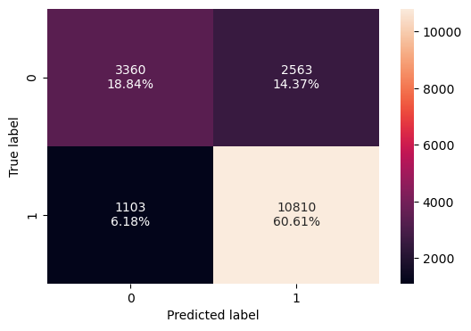

```python
# Create confusion matrices
confusion_matrix_sklearn(rf_tuned, X_train, y_train)  # Train data
```

#### Test set

```python
# Evaluate performance on test data
rf_tuned_model_test_perf = model_performance_classification_sklearn(rf_tuned, X_test, y_test)
rf_tuned_model_test_perf
```

|  | Accuracy | Recall | Precision | F1 |
| --- | --- | --- | --- | --- |
| 0 | 0.742936 | 0.87287 | 0.772003 | 0.819344 |

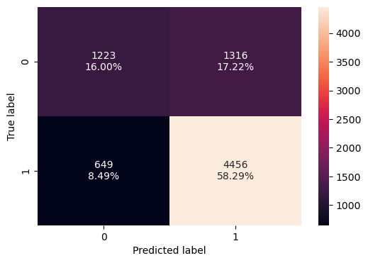

```python
# Create confusion matrices
confusion_matrix_sklearn(rf_tuned, X_test, y_test)  # Test data
```

- The hyper parameter tunning - random forest reduced overfitting
- Compared to the untuned model random forest, the training accuracy dropped from 100% to 79.45%, meaning it generalizes better.
- Recall improved from 83.96% (untuned) to 87.29% which indicates that the model is better at identifying visa approvals.

## Boosting

### Adaboosting

```python
# Define AdaBoost Classifier with random state = 1
ab_classifier = AdaBoostClassifier(random_state=1)

# Fit AdaBoost Classifier on the train data
ab_classifier.fit(X_train, y_train)
```

```
AdaBoostClassifier(random_state=1)
```

#### Train set

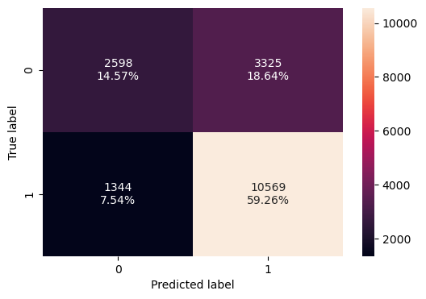

```python
# Create confusion matrices
confusion_matrix_sklearn(ab_classifier, X_train, y_train)  # Train data
```

```python
# Check performance on train data
ab_classifier_model_train_perf = model_performance_classification_sklearn(ab_classifier, X_train, y_train)
ab_classifier_model_train_perf
```

|  | Accuracy | Recall | Precision | F1 |
| --- | --- | --- | --- | --- |
| 0 | 0.738226 | 0.887182 | 0.760688 | 0.81908 |

#### Test set

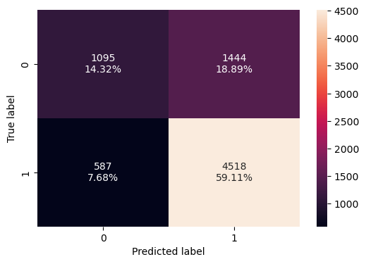

```python
# Create confusion matrix for test data
confusion_matrix_sklearn(ab_classifier, X_test, y_test)
```

```python
ab_classifier_model_test_perf = model_performance_classification_sklearn(ab_classifier, X_test, y_test)
ab_classifier_model_test_perf
```

|  | Accuracy | Recall | Precision | F1 |
| --- | --- | --- | --- | --- |
| 0 | 0.734301 | 0.885015 | 0.757799 | 0.816481 |

- Adaboost has a consistent performance across train and test sets.
- The model generalizes well, with minimal overfitting.
- It has a high Recall (88.50%). The model is good at identifying visa approvals, minimizing false negatives.

### Hyperparameter Tuning - AdaBoost

```python
param_grid_adaboost = {
    "n_estimators": np.arange(50,110,25),
    "learning_rate": [0.01,0.1,0.05],
    "estimator": [
        DecisionTreeClassifier(max_depth=2, random_state=1),
        DecisionTreeClassifier(max_depth=3, random_state=1),
    ],
}
```

```python
# Define AdaBoost classifier
ab_tuned = AdaBoostClassifier(random_state=1)

# Define scoring metric
acc_scorer = metrics.make_scorer(metrics.f1_score)

# Perform grid search
grid_obj = GridSearchCV(ab_tuned, param_grid_adaboost, scoring=acc_scorer, cv=5, n_jobs=-1)
grid_obj = grid_obj.fit(X_train, y_train)

# Get the best estimator
ab_tuned = grid_obj.best_estimator_

# Fit the best model
ab_tuned.fit(X_train, y_train)
```

[output not shown]

[output not shown]

```
AdaBoostClassifier(estimator=DecisionTreeClassifier(max_depth=3,
                                                    random_state=1),
                   learning_rate=0.1, random_state=1)
```

#### Train set

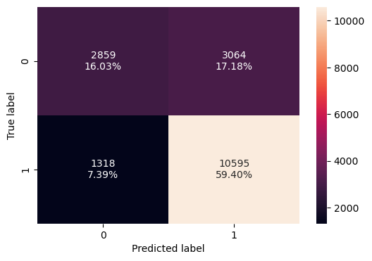

```python
confusion_matrix_sklearn(ab_tuned, X_train, y_train)
```

```python
abc_tuned_model_train_perf = model_performance_classification_sklearn(ab_tuned, X_train, y_train)
abc_tuned_model_train_perf
```

|  | Accuracy | Recall | Precision | F1 |
| --- | --- | --- | --- | --- |
| 0 | 0.754317 | 0.889365 | 0.775679 | 0.828641 |

#### Test set

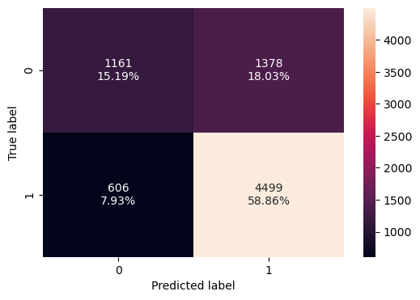

```python
confusion_matrix_sklearn(ab_tuned, X_test, y_test)
```

```python
abc_tuned_model_test_perf = model_performance_classification_sklearn(ab_tuned, X_test, y_test)
abc_tuned_model_test_perf
```

|  | Accuracy | Recall | Precision | F1 |
| --- | --- | --- | --- | --- |
| 0 | 0.74045 | 0.881293 | 0.765527 | 0.819341 |

- Hyper parameter tunning adaboost has an improvement in precision and F1.
- Precision increased from 75.78% to 76.55%, meaning fewer false positives.
- F1-score increased slightly (from 81.65% to 81.93%), ensuring a better balance between precision and recall.

### Gradient Boosting

```python
gb_classifier = GradientBoostingClassifier(random_state=1)  ## Define Gradient Boosting Classifier
gb_classifier.fit(X_train, y_train)  ## Fit the model on the train data
```

```
GradientBoostingClassifier(random_state=1)
```

#### Train set

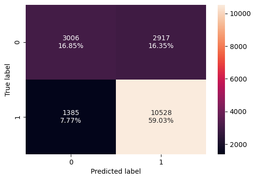

```python
# Create confusion matrix for train data
confusion_matrix_sklearn(gb_classifier, X_train, y_train)
```

```python
# Check model performance on train data
gb_classifier_model_train_perf = model_performance_classification_sklearn(gb_classifier, X_train, y_train)
gb_classifier_model_train_perf
```

|  | Accuracy | Recall | Precision | F1 |
| --- | --- | --- | --- | --- |
| 0 | 0.758802 | 0.88374 | 0.783042 | 0.830349 |

#### Test set

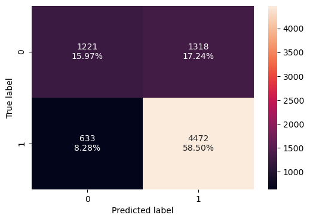

```python
# Create confusion matrix for test data
confusion_matrix_sklearn(gb_classifier, X_test, y_test)
```

```python
# Check model performance on test data
gb_classifier_model_test_perf = model_performance_classification_sklearn(gb_classifier, X_test, y_test)
gb_classifier_model_test_perf
```

|  | Accuracy | Recall | Precision | F1 |
| --- | --- | --- | --- | --- |
| 0 | 0.744767 | 0.876004 | 0.772366 | 0.820927 |

- Lower or no overfitting compared to other models.
- Unlike Random Forest and Bagging Classifier, Gradient Boosting doesn’t overfit.
- There's no gap between train and test performance.
- It has good generalization.
- Recall remains high (87.6%), ensuring most visa approvals are correctly classified.

### Hyperparameter Tuning - Gradient Boosting

```python
# Choose the type of classifier.
gbc_tuned = GradientBoostingClassifier(random_state=1)

# Grid of parameters to choose from
parameters = {
    "n_estimators": np.arange(50, 110, 25),
    "learning_rate": [0.01, 0.1, 0.05],
    "subsample": [0.7, 0.9],
    "max_features": [0.5, 0.7, 1],
    "max_depth": [3, 5],  # Controls the complexity of individual trees
    "min_samples_leaf": [1, 3, 5],  # Prevents overfitting
}

# Type of scoring used to compare parameter combinations
acc_scorer = metrics.make_scorer(metrics.f1_score)

# Run the grid search
grid_obj = GridSearchCV(gbc_tuned, parameters, scoring=acc_scorer, cv=5, n_jobs=-1)

# Fit the grid search on train data
grid_obj.fit(X_train, y_train)

# Set the classifier to the best combination of parameters
gbc_tuned = grid_obj.best_estimator_

# Fit the best algorithm to the data
gbc_tuned.fit(X_train, y_train)
```

```
GradientBoostingClassifier(learning_rate=0.05, max_depth=5, max_features=0.7,
                           min_samples_leaf=3, n_estimators=50, random_state=1,
                           subsample=0.7)
```

#### Train set

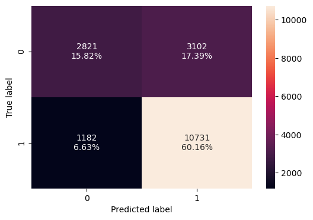

```python
# Create confusion matrix for train data on tuned estimator
confusion_matrix_sklearn(gbc_tuned, X_train, y_train)
```

```python
# Check performance for train data on tuned estimator
gbc_tuned_model_train_perf = model_performance_classification_sklearn(gbc_tuned, X_train, y_train)
gbc_tuned_model_train_perf
```

|  | Accuracy | Recall | Precision | F1 |
| --- | --- | --- | --- | --- |
| 0 | 0.759812 | 0.900781 | 0.775754 | 0.833605 |

#### Test set

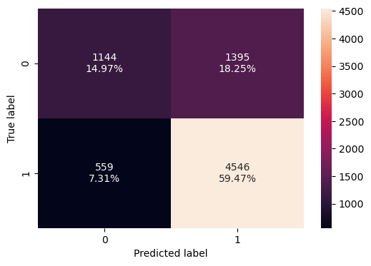

```python
confusion_matrix_sklearn(gbc_tuned, X_test, y_test)
```

```python
gbc_tuned_model_test_perf = model_performance_classification_sklearn(gbc_tuned, X_test, y_test)
gbc_tuned_model_test_perf
```

|  | Accuracy | Recall | Precision | F1 |
| --- | --- | --- | --- | --- |
| 0 | 0.744375 | 0.8905 | 0.765191 | 0.823103 |

- Hyperparameter Tuning - Gradient Boosting model has some improvements.
- It is a well balanced model, no overfitting. Generalizes well.
- It has a higher recall (90.08%) on train and (89.05%) on test.

### Stacking

```python
estimators = [
    ("AdaBoost", ab_classifier),
    ("Gradient Boosting", gbc_tuned),
    ("Random Forest", rf_tuned),
]
```

```python
# Define the Stacking Classifier
stacking_classifier = StackingClassifier(estimators=estimators, final_estimator=LogisticRegression(), n_jobs=-1)

# Fit the Stacking Classifier on the train data
stacking_classifier.fit(X_train, y_train)
```

```
StackingClassifier(estimators=[('AdaBoost', AdaBoostClassifier(random_state=1)),
                               ('Gradient Boosting',
                                GradientBoostingClassifier(learning_rate=0.05,
                                                           max_depth=5,
                                                           max_features=0.7,
                                                           min_samples_leaf=3,
                                                           n_estimators=50,
                                                           random_state=1,
                                                           subsample=0.7)),
                               ('Random Forest',
                                RandomForestClassifier(max_samples=0.4,
                                                       min_samples_leaf=3,
                                                       n_estimators=110,
                                                       oob_score=True,
                                                       random_state=1))],
                   final_estimator=LogisticRegression(), n_jobs=-1)
```

#### Train set

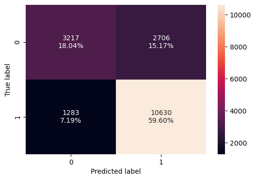

```python
confusion_matrix_sklearn(stacking_classifier, X_train, y_train)
```

```python
# Check performance on train data
stacking_classifier_model_train_perf = model_performance_classification_sklearn(stacking_classifier, X_train, y_train)
stacking_classifier_model_train_perf
```

|  | Accuracy | Recall | Precision | F1 |
| --- | --- | --- | --- | --- |
| 0 | 0.776351 | 0.892303 | 0.797091 | 0.842014 |

#### Test set

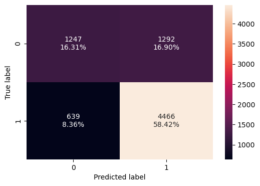

```python
confusion_matrix_sklearn(stacking_classifier, X_test, y_test)
```

```python
stacking_classifier_model_test_perf = model_performance_classification_sklearn(stacking_classifier, X_test, y_test)
stacking_classifier_model_test_perf
```

|  | Accuracy | Recall | Precision | F1 |
| --- | --- | --- | --- | --- |
| 0 | 0.747384 | 0.874829 | 0.775617 | 0.822241 |

- Stacking model has balanced recall (87.48%) and precision (77.56%)
- No overfitting.
- Perform well with unseen data.
- There is no sigificant gap between train and test sets.
- Better overall balance compared to other models, indicating that stacking performs well in both minimizing false positives and false negatives.

## Model Performance Comparison and Conclusions

```python
# training performance comparison

models_train_comp_df = pd.concat(
    [
        decision_tree_perf_train.T,
        dtree_tuned_model_perf_train.T,
        bagging_classifier_model_train_perf.T,
        bagging_estimator_tuned_model_train_perf.T,
        rf_estimator_model_train_perf.T,
        rf_tuned_model_train_perf.T,
        ab_classifier_model_train_perf.T,
        abc_tuned_model_train_perf.T,
        gb_classifier_model_train_perf.T,
        gbc_tuned_model_train_perf.T,
        stacking_classifier_model_train_perf.T,
    ],
    axis=1,
)
models_train_comp_df.columns = [
    "Decision Tree",
    "Tuned Decision Tree",
    "Bagging Classifier",
    "Tuned Bagging Classifier",
    "Random Forest",
    "Tuned Random Forest",
    "Adaboost Classifier",
    "Tuned Adaboost Classifier",
    "Gradient Boost Classifier",
    "Tuned Gradient Boost Classifier",
    "Stacking Classifier",
]
print("Training performance comparison:")
models_train_comp_df
```

```
Training performance comparison:
```

|  | Decision Tree | Tuned Decision Tree | Bagging Classifier | Tuned Bagging Classifier | Random Forest | Tuned Random Forest | Adaboost Classifier | Tuned Adaboost Classifier | Gradient Boost Classifier | Tuned Gradient Boost Classifier | Stacking Classifier |
| --- | --- | --- | --- | --- | --- | --- | --- | --- | --- | --- | --- |
| Accuracy | 1.0 | 0.710193 | 0.985030 | 0.998598 | 1.0 | 0.794461 | 0.738226 | 0.754317 | 0.758802 | 0.759812 | 0.776351 |
| Recall | 1.0 | 0.725762 | 0.985562 | 0.999916 | 1.0 | 0.907412 | 0.887182 | 0.889365 | 0.883740 | 0.900781 | 0.892303 |
| Precision | 1.0 | 0.819681 | 0.991974 | 0.997989 | 1.0 | 0.808345 | 0.760688 | 0.775679 | 0.783042 | 0.775754 | 0.797091 |
| F1 | 1.0 | 0.769868 | 0.988757 | 0.998952 | 1.0 | 0.855019 | 0.819080 | 0.828641 | 0.830349 | 0.833605 | 0.842014 |

```python
# Test performance comparison
models_test_comp_df = pd.concat(
    [
        decision_tree_perf_test.T,
        dtree_tuned_model_perf_test.T,
        bagging_classifier_model_test_perf.T,
        bagging_estimator_tuned_model_test_perf.T,
        rf_estimator_model_test_perf.T,
        rf_tuned_model_test_perf.T,
        ab_classifier_model_test_perf.T,
        abc_tuned_model_test_perf.T,
        gb_classifier_model_test_perf.T,
        gbc_tuned_model_test_perf.T,
        stacking_classifier_model_test_perf.T,
    ],
    axis=1,
)
models_test_comp_df.columns = [
    "Decision Tree",
    "Tuned Decision Tree",
    "Bagging Classifier",
    "Tuned Bagging Classifier",
    "Random Forest",
    "Tuned Random Forest",
    "Adaboost Classifier",
    "Tuned Adaboost Classifier",
    "Gradient Boost Classifier",
    "Tuned Gradient Boost Classifier",
    "Stacking Classifier",
]
print("Test performance comparison:")
models_test_comp_df
```

```
Test performance comparison:
```

|  | Decision Tree | Tuned Decision Tree | Bagging Classifier | Tuned Bagging Classifier | Random Forest | Tuned Random Forest | Adaboost Classifier | Tuned Adaboost Classifier | Gradient Boost Classifier | Tuned Gradient Boost Classifier | Stacking Classifier |
| --- | --- | --- | --- | --- | --- | --- | --- | --- | --- | --- | --- |
| Accuracy | 0.664835 | 0.707483 | 0.692700 | 0.725144 | 0.722004 | 0.742936 | 0.734301 | 0.740450 | 0.744767 | 0.744375 | 0.747384 |
| Recall | 0.742801 | 0.726543 | 0.766503 | 0.888345 | 0.839569 | 0.872870 | 0.885015 | 0.881293 | 0.876004 | 0.890500 | 0.874829 |
| Precision | 0.752232 | 0.815344 | 0.771795 | 0.747610 | 0.766452 | 0.772003 | 0.757799 | 0.765527 | 0.772366 | 0.765191 | 0.775617 |
| F1 | 0.747487 | 0.768386 | 0.769140 | 0.811924 | 0.801346 | 0.819344 | 0.816481 | 0.819341 | 0.820927 | 0.823103 | 0.822241 |

## Actionable Insights and Recommendations

### Key factors that influence visa approval

1. Higher education increases visa approval chances. Applicants with a master's and bachelor's degree have the highest count of certified visas. Almost 78% of the applicants have a bachelor's or master's degree. Since education plays a significant role in visa certification, the company should prioritize applicants with higher education levels because it can lead to higher chances of obtaining a visa.
2. Work experience is important. 58.1% of applicant have prior job experience and it is correlated with higher visa approval rates. Experienced professionals have better chances of getting a visa.
3. Yearly wages have a significant impact. 69.89% of applicants with yearly salaries got their visas certified, making it the most favorable pay unit. Visa approvals are higher for stable, full time position hence, long-term stable jobs are preferred.
4. Job training is not a determined factor, 88.4% of jobs do not require training. Instead emoployers prefer applicants who already have the necessary skills to perform the labor.
5. Visa demand varies by region. There are highest demand in Norteast (28.2%), South (27.5%) and West (25.8%) regions. Applications for positions these regions of the U.S. have higher approval rates, likely due to demand in these areas.
6. Higher prevailing wages are associated with a slightly higher likelihood of visa certification. The mean prevailing wage for certified cases is 77.293, suggesting that competitive salaries improve the chances of visa approval.

#### Recommendations

- Organizations should prioritize applicants with higher education credentials when selecting candidates.
- Employers should highlight work experience in visa applications to improve approval chances.
- Prefer candidates with pre-existing skills (less training needed).
- Applicants should acquire relevant skills before applying to increase their approval odds.
- Applicants can target high-demand regions for better chances of approval.
- Offer annual salary contracts for higher stability and visa approval rates.
- Use stacking classifier model or tuned gradient boosting classifier model for the most accurate and reliable visa approval predictions.
- Regularly update the model with new visa applicant data.